# Inference, hypothesis testing, and sampling

Jorge Alonso

2026-05-25

# 1. Preparing

## 1.1. Loading packages and data

```r
# Loading packages
library(tidyverse)
library(patchwork)
library(DescTools)
library(infer)
library(car)
```

```r
# Cleaning memory
rm(list = ls(all = TRUE))
gc()
```

```
##           used  (Mb) gc trigger  (Mb) max used  (Mb)
## Ncells 2448993 130.8    4446225 237.5  4446225 237.5
## Vcells 4184536  32.0    8388608  64.0  6901032  52.7
```

```r
# Database link
processed_url <- "https://raw.githubusercontent.com/jmalonso55/Applied-Statistics-for-a-Tropical-Arboretum/refs/heads/main/data/processed_data.csv"
```

```r
# Loading data
data_trab <- read.csv(processed_url, sep = ",")

# Checking
summary(data_trab)
```

```
##       sec_cant        tombo            family           genus
##  Length   :4621   Min.   :   1   Length   :4621   Length   :4621
##  N.unique : 214   1st Qu.:2145   N.unique :  82   N.unique : 460
##  N.blank  :   0   Median :4524   N.blank  :   0   N.blank  :   0
##  Min.nchar:   2   Mean   :4434   Min.nchar:   8   Min.nchar:   4
##  Max.nchar:  18   3rd Qu.:6640   Max.nchar:  16   Max.nchar:  16
##                   Max.   :9180   NAs      : 157   NAs      : 334
##       species            name          habito_pad       altura
##  Length   :4621   Length   :4621   Length   :4621   Min.   : 1.30
##  N.unique : 672   N.unique : 814   N.unique :   7   1st Qu.: 8.69
##  N.blank  :   0   N.blank  :   0   N.blank  :   0   Median :13.06
##  Min.nchar:   4   Min.nchar:   9   Min.nchar:   4   Mean   :14.28
##  Max.nchar:  17   Max.nchar:  30   Max.nchar:  13   3rd Qu.:18.54
##  NAs      : 615   NAs      : 615                    Max.   :44.35
##       dap           densidade         n_caule         multicaule
##  Min.   : 10.19   Min.   :0.1500   Min.   : 1.000   Min.   :0.0000
##  1st Qu.: 23.30   1st Qu.:0.5200   1st Qu.: 1.000   1st Qu.:0.0000
##  Median : 36.61   Median :0.5500   Median : 1.000   Median :0.0000
##  Mean   : 44.42   Mean   :0.6026   Mean   : 1.467   Mean   :0.1489
##  3rd Qu.: 60.16   3rd Qu.:0.7100   3rd Qu.: 1.000   3rd Qu.:0.0000
##  Max.   :224.54   Max.   :1.2300   Max.   :42.000   Max.   :1.0000
##     multicaule_l      rel_hd          area_basal
##  Length   :4621   Min.   :0.02199   Min.   :0.008155
##  N.unique :   2   1st Qu.:0.24821   1st Qu.:0.042635
##  N.blank  :   0   Median :0.35000   Median :0.105266
##  Min.nchar:   2   Mean   :0.38255   Mean   :0.219827
##  Max.nchar:   3   3rd Qu.:0.48179   3rd Qu.:0.284253
##                   Max.   :2.09473   Max.   :3.959837
```

## 1.2. Functions

```r
# Coefficient of variation function
cv <- function(x) {
  sd(x) / mean(x) * 100
  }
```

```r
# Function for descriptive statistics of height
summary_height <- function(data) {
  data %>% summarise(n = n(), mean_height = mean(altura), sd_height = sd(altura), cv_height = cv(altura), median_height = median(altura))
  }
```

```r
# Function to compare a sample with the reference population
compare_sample <- function(sample_data, population_data, var) {

  pop_values <- population_data %>% pull({{ var }})
  sample_values <- sample_data %>% pull({{ var }})

  tibble(statistic = c("mean", "median", "sd", "cv", "q25", "q75", "p90", "p95"),
    population = c(mean(pop_values), median(pop_values), sd(pop_values), cv(pop_values), quantile(pop_values, 0.25), quantile(pop_values, 0.75), quantile(pop_values, 0.90), quantile(pop_values, 0.95)),
    sample = c(mean(sample_values), median(sample_values), sd(sample_values), cv(sample_values), quantile(sample_values, 0.25), quantile(sample_values, 0.75), quantile(sample_values, 0.90), quantile(sample_values, 0.95))) %>%
    mutate(absolute_error = sample - population, relative_error_percent = absolute_error / population * 100)
}
```

# 2. Population and sample

## 2.1. Population parameters: mean, standard deviation, and distribution

```r
# Random sample of 50 plants
set.seed(123)
amostra_50 <- data_trab %>%
  slice_sample(n = 50)
```

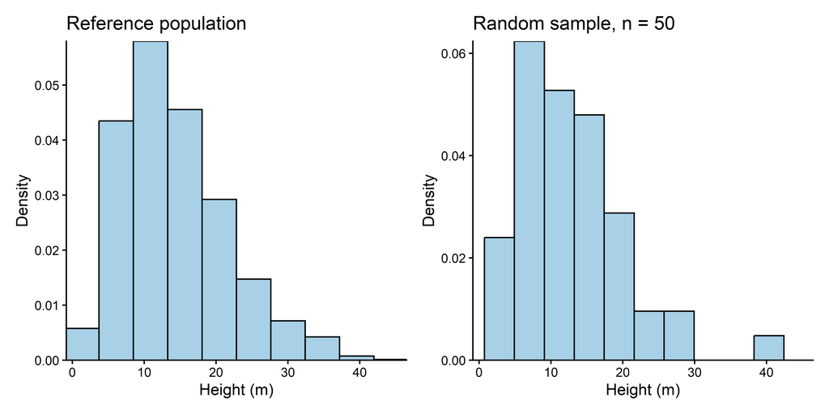

```r
# Comparing the height distribution in the reference population and in a random sample

# Common x-axis limits
x_lim <- range(data_trab$altura)

# Population histogram
hist_pop <-
  ggplot(data_trab, aes(x = altura)) +
  geom_histogram(aes(y = after_stat(density)), bins = 10, fill = "#A8D0E6", color = "black") +
  coord_cartesian(xlim = x_lim) +
  labs(x = "Height (m)", y = "Density") +
  scale_y_continuous(expand = c(0, 0)) +
  theme_classic()

# Sample histogram
hist_amo <-
  ggplot(amostra_50, aes(x = altura)) +
  geom_histogram(aes(y = after_stat(density)), bins = 10, fill = "#A8D0E6", color = "black") +
  coord_cartesian(xlim = x_lim) +
  labs(x = "Height (m)", y = "Density") +
  scale_y_continuous(expand = c(0, 0)) +
  theme_classic()

# Visualizing
hist_pop <- hist_pop + ggtitle("Reference population")
hist_amo <- hist_amo + ggtitle("Random sample, n = 50")

hist_pop + hist_amo
```

```r
# Parameter: population mean
# For didactic purposes, the census dataset is treated as the reference population.
m_pop <- mean(data_trab$altura)
paste("Parameter - Population mean =", round(m_pop, 2), "m")
```

```
## [1] "Parameter - Population mean = 14.28 m"
```

```r
# Estimate: sample mean
# The estimator is the sample mean; the estimate is the value obtained in this sample.
m_amo <- mean(amostra_50$altura)
paste("Estimate - Sample mean =", round(m_amo, 2), "m")
```

```
## [1] "Estimate - Sample mean = 12.97 m"
```

```r
# Sampling error for this specific sample
erro_amostral <- m_amo - m_pop
paste("Sampling error =", round(erro_amostral, 2), "m")
```

```
## [1] "Sampling error = -1.31 m"
```

```r
# Parameter: population standard deviation
sd_pop <- sqrt(sum((data_trab$altura - mean(data_trab$altura))^2) /
    sum(!is.na(data_trab$altura)))
paste("Parameter - Population standard deviation =", round(sd_pop, 2), "m")
```

```
## [1] "Parameter - Population standard deviation = 7.36 m"
```

```r
# Estimate: sample standard deviation
sd_amo <- sd(amostra_50$altura, na.rm = TRUE)
paste("Estimate - Sample standard deviation =", round(sd_amo, 2), "m")
```

```
## [1] "Estimate - Sample standard deviation = 7.34 m"
```

## 2.2. Exploring properties of estimators

```r
# Repeated sampling to evaluate the behavior of the sample mean
set.seed(123)

estimativas <- tibble(n_amostral = c(5, 25, 100)) %>%
  mutate(estimativas = map(n_amostral, ~ replicate(n = 1000, expr = mean(sample(data_trab$altura, size = .x, replace = FALSE))))) %>%
  unnest_longer(estimativas) %>%
  group_by(n_amostral) %>%
  mutate(simulacao = row_number()) %>%
  ungroup()

# Checking the behavior of the estimator
estimativas %>%
  group_by(n_amostral) %>%
  reframe(mean_estimate = mean(estimativas), bias = mean(estimativas) - m_pop, sd_estimate = sd(estimativas))
```

```
## # A tibble: 3 × 4
##   n_amostral mean_estimate      bias sd_estimate
##        <dbl>         <dbl>     <dbl>       <dbl>
## 1          5          14.2 -0.130          3.32
## 2         25          14.3  0.0188         1.41
## 3        100          14.3 -0.000414       0.711
```

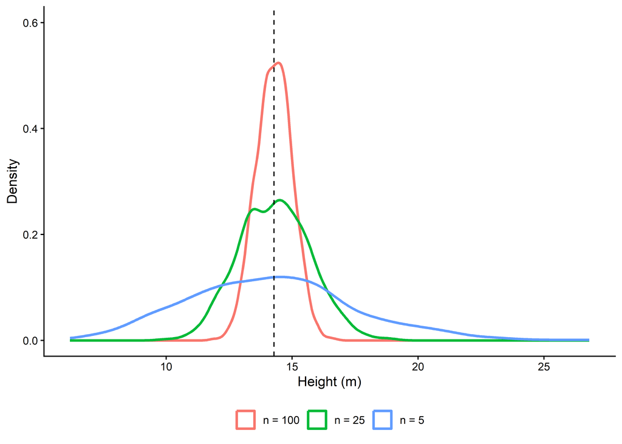

```r
# Visualizing the sampling distribution of the sample mean
estimativas %>%
  mutate(n_amostral = factor(n_amostral, levels = c(100, 25, 5), labels = c("n = 100", "n = 25", "n = 5"))) %>%
  ggplot(aes(x = estimativas, color = n_amostral)) +
  geom_density(linewidth = 1) +
  geom_vline(xintercept = m_pop, linetype = "dashed") +
  coord_cartesian(ylim = c(0, 0.6)) +
  labs(x = "Height (m)", y = "Density", color = NULL) +
  theme_classic() +
  theme(legend.position = "bottom",
    legend.background = element_rect(fill = "white", color = NA))
```

As the sample size increases, the sampling distribution of the sample mean becomes more concentrated around the population mean. This illustrates that the sample mean is a consistent estimator of the population mean.

## 2.3. Central Limit Theorem and sampling distributions

```r
# Population parameter: proportion of multi-stemmed plants
mul_pop <- mean(data_trab$multicaule)

# Generating repeated random samples
# For a binary variable, the sample mean corresponds to the sample proportion.
set.seed(123)
amostras_mul <- tibble(amostra = 1:1000) %>%
  mutate(dados = map(amostra, ~ data_trab %>%
                       slice_sample(n = 100, replace = TRUE))) %>%
  unnest(dados)
```

```r
# Calculating the sample proportion of multi-stemmed plants in each sample
estimativas_mul <- amostras_mul %>%
  group_by(amostra) %>%
  summarise(n = n(), prop_multicaule = mean(multicaule), sd_multicaule = sd(multicaule), .groups = "drop")

head(estimativas_mul, 10)
```

```
## # A tibble: 10 × 4
##    amostra     n prop_multicaule sd_multicaule
##      <int> <int>           <dbl>         <dbl>
##  1       1   100            0.18         0.386
##  2       2   100            0.15         0.359
##  3       3   100            0.09         0.288
##  4       4   100            0.14         0.349
##  5       5   100            0.1          0.302
##  6       6   100            0.21         0.409
##  7       7   100            0.15         0.359
##  8       8   100            0.14         0.349
##  9       9   100            0.22         0.416
## 10      10   100            0.11         0.314
```

```r
# Summary of the simulated sampling distribution
estimativas_mul %>%
  summarise(mean_of_sample_proportions = mean(prop_multicaule), sd_of_sample_proportions = sd(prop_multicaule), population_proportion = mul_pop)
```

```
## # A tibble: 1 × 3
##   mean_of_sample_proportions sd_of_sample_proportions population_proportion
##                        <dbl>                    <dbl>                 <dbl>
## 1                      0.149                   0.0355                 0.149
```

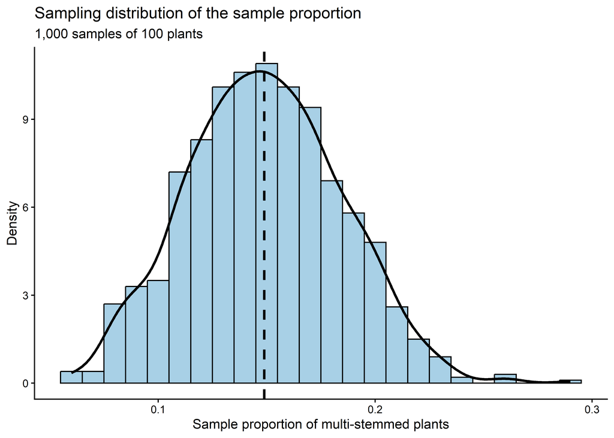

```r
# Visualizing the sampling distribution of the sample proportion
ggplot(estimativas_mul, aes(x = prop_multicaule)) +
  geom_histogram(aes(y = after_stat(density)), bins = 24, fill = "#A8D0E6", color = "black") +
  geom_density(linewidth = 1) +
  geom_vline(xintercept = mul_pop, linetype = "dashed", linewidth = 1) +
  labs(x = "Sample proportion of multi-stemmed plants", y = "Density", title = "Sampling distribution of the sample proportion", subtitle = "1,000 samples of 100 plants") +
  theme_classic()
```

Because multicaule is a binary variable, its sample mean represents the sample proportion of multi-stemmed plants. The simulated distribution shows how this proportion varies across repeated samples. According to the Central Limit Theorem, as the sample size increases, the sampling distribution of the sample mean tends to become approximately normal, even when the original variable is binary.

# 3. Confidence intervals

## 3.1. Confidence interval for the mean

```r
# Confidence interval for the mean height based on one random sample of 50 plants
ic_50 <- MeanCI(amostra_50$altura, conf.level = 0.95)
ic_50
```

```
##     mean   lwr.ci   upr.ci
## 12.97060 10.88419 15.05701
```

```r
# Checking whether the confidence interval contains the population mean
ic_50["lwr.ci"] <= m_pop & ic_50["upr.ci"] >= m_pop
```

```
## lwr.ci
##   TRUE
```

## 3.2. Confidence intervals and coverage

```r
# Simulating several confidence intervals from repeated samples
set.seed(123)
ic_sim <- tibble(amostra = 1:100) %>%
  mutate(dados = map(amostra, ~ sample(data_trab$altura, size = 50, replace = FALSE)), ic = map(dados, ~ MeanCI(.x, conf.level = 0.95))) %>%
  mutate(media = map_dbl(ic, ~ .x["mean"]), lower = map_dbl(ic, ~ .x["lwr.ci"]), upper = map_dbl(ic, ~ .x["upr.ci"]), contains_mean = lower <= m_pop & upper >= m_pop) %>%
  select(amostra, media, lower, upper, contains_mean)

head(ic_sim)
```

```
## # A tibble: 6 × 5
##   amostra media lower upper contains_mean
##     <int> <dbl> <dbl> <dbl> <lgl>
## 1       1  13.0  10.9  15.1 TRUE
## 2       2  13.8  11.9  15.8 TRUE
## 3       3  15.1  13.1  17.0 TRUE
## 4       4  14.1  11.9  16.2 TRUE
## 5       5  13.5  11.7  15.3 TRUE
## 6       6  15.5  13.2  17.8 TRUE
```

```r
# Proportion of confidence intervals that contain the population mean
ic_sim %>%
  summarise(n_intervals = n(), confidence_level = 0.95, coverage = mean(contains_mean))
```

```
## # A tibble: 1 × 3
##   n_intervals confidence_level coverage
##         <int>            <dbl>    <dbl>
## 1         100             0.95     0.94
```

## 3.3. Effect of the confidence level on interval width

```r
# Comparing confidence intervals with different confidence levels
# The same random sample is used in all cases.
ic_levels <- tibble(confidence_level = c(0.90, 0.95, 0.99)) %>%
  mutate(ic = map(confidence_level, ~ MeanCI(amostra_50$altura, conf.level = .x)), mean = map_dbl(ic, ~ .x["mean"]), lower = map_dbl(ic, ~ .x["lwr.ci"]), upper = map_dbl(ic, ~ .x["upr.ci"]), width = upper - lower, contains_population_mean = lower <= m_pop & upper >= m_pop) %>%
  select(confidence_level, mean, lower, upper, width, contains_population_mean)

ic_levels
```

```
## # A tibble: 3 × 6
##   confidence_level  mean lower upper width contains_population_mean
##              <dbl> <dbl> <dbl> <dbl> <dbl> <lgl>
## 1             0.9   13.0  11.2  14.7  3.48 TRUE
## 2             0.95  13.0  10.9  15.1  4.17 TRUE
## 3             0.99  13.0  10.2  15.8  5.56 TRUE
```

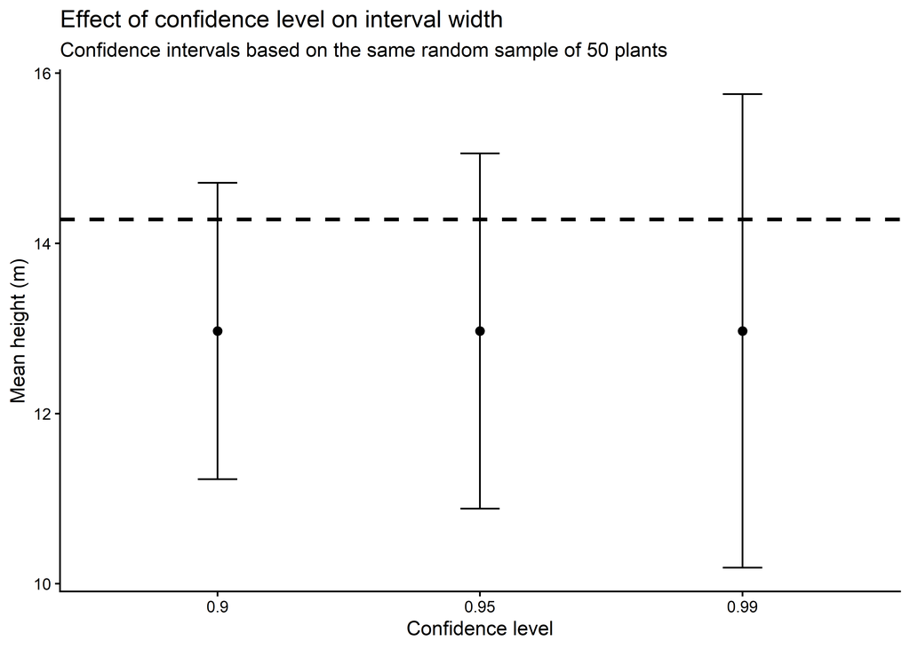

```r
# Visualizing the effect of the confidence level on interval width
ggplot(ic_levels, aes(x = factor(confidence_level), y = mean)) +
  geom_hline(yintercept = m_pop, linetype = "dashed", linewidth = 1) +
  geom_errorbar(aes(ymin = lower, ymax = upper), width = 0.15) +
  geom_point(size = 2) +
  labs(x = "Confidence level", y = "Mean height (m)", title = "Effect of confidence level on interval width", subtitle = "Confidence intervals based on the same random sample of 50 plants") +
  theme_classic()
```

This section illustrates how confidence intervals quantify the uncertainty of sample-based estimates. The census dataset is treated as the reference population, allowing the true population mean to be compared with intervals calculated from random samples. This makes it possible to show that a single confidence interval either contains or does not contain the population mean, whereas the confidence level refers to the long-term proportion of intervals that would contain the parameter under repeated sampling. The section also demonstrates that higher confidence levels produce wider intervals for the same sample because they require a larger margin of error.

# 4. Hypothesis testing

## 4.1. Comparing one group with a reference value from the arboretum

### 4.1.1. Non-parametric test: height in bed 26F

```r
# Filtering the 26F bed and the remaining arboretum records
canteiro_26F <- data_trab %>%
  filter(sec_cant == "26F")

menos_26F <- data_trab %>%
  filter(sec_cant != "26F")
```

```r
# Descriptive statistics for the 26F bed
summary_height(canteiro_26F)
```

```
##     n mean_height sd_height cv_height median_height
## 1 111    24.72973  7.672424   31.0251         25.15
```

```r
# Descriptive statistics for the remaining arboretum records
summary_height(menos_26F)
```

```
##      n mean_height sd_height cv_height median_height
## 1 4510    14.02505  7.166023  51.09447          12.9
```

```r
# Checking normality in the 26F bed
shapiro.test(canteiro_26F$altura)
```

```
##
##  Shapiro-Wilk normality test
##
## data:  canteiro_26F$altura
## W = 0.93863, p-value = 6.802e-05
```

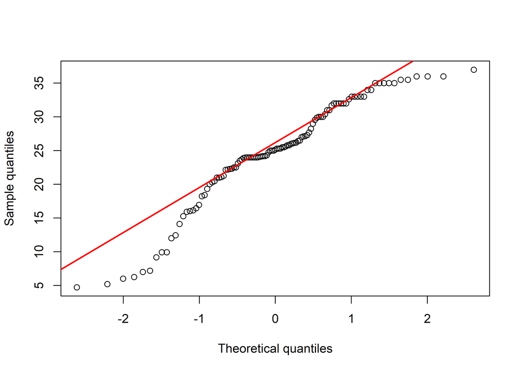

```r
# Graphical assessment of normality
qqnorm(canteiro_26F$altura, main = "", xlab = "Theoretical quantiles", ylab = "Sample quantiles")
qqline(canteiro_26F$altura, col = "red", lwd = 2)
```

```r
# Testing whether height values in the 26F bed are greater than the median height of the remaining arboretum records
mediana_ref_26F <- median(menos_26F$altura)

wilcox.test(canteiro_26F$altura, mu = mediana_ref_26F, alternative = "greater")
```

```
##
##  Wilcoxon signed rank test with continuity correction
##
## data:  canteiro_26F$altura
## V = 6073, p-value < 2.2e-16
## alternative hypothesis: true location is greater than 12.9
```

### 4.1.2. Parametric test: height in Moraceae

```r
# Filtering Moraceae and the remaining arboretum records
moraceae <- data_trab %>%
  filter(family == "Moraceae")

sem_moraceae <- data_trab %>%
  filter(family != "Moraceae")
```

```r
# Descriptive statistics for Moraceae
summary_height(moraceae)
```

```
##     n mean_height sd_height cv_height median_height
## 1 133    15.90729  5.129378  32.24545         16.34
```

```r
# Descriptive statistics for the remaining arboretum records
summary_height(sem_moraceae)
```

```
##      n mean_height sd_height cv_height median_height
## 1 4331    14.26934  7.467065  52.32945         12.98
```

```r
# Checking normality in Moraceae
shapiro.test(moraceae$altura)
```

```
##
##  Shapiro-Wilk normality test
##
## data:  moraceae$altura
## W = 0.99057, p-value = 0.5089
```

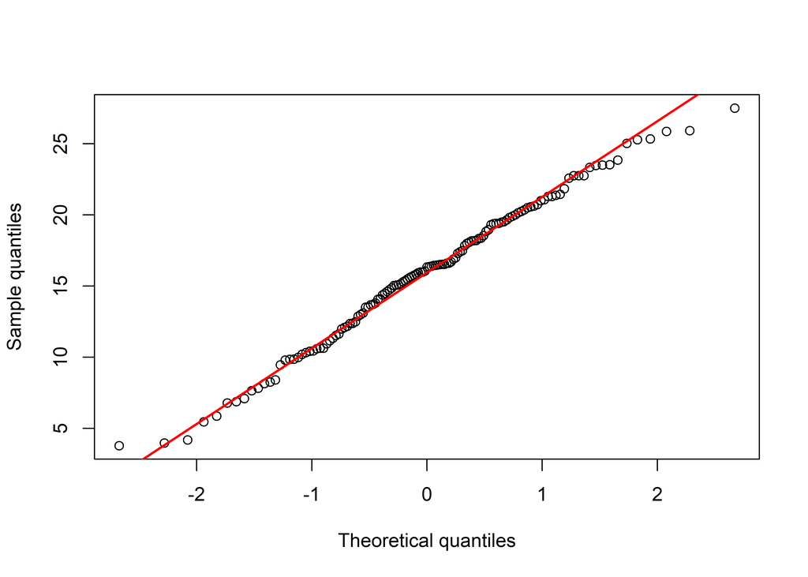

```r
# Graphical assessment of normality
qqnorm(moraceae$altura, main = "", xlab = "Theoretical quantiles", ylab = "Sample quantiles")
qqline(moraceae$altura, col = "red", lwd = 2)
```

```r
# Testing whether the mean height of Moraceae differs from the mean height of the remaining arboretum records
media_ref_moraceae <- mean(sem_moraceae$altura)

t.test(moraceae$altura, mu = media_ref_moraceae, alternative = "two.sided")
```

```
##
##  One Sample t-test
##
## data:  moraceae$altura
## t = 3.6827, df = 132, p-value = 0.0003354
## alternative hypothesis: true mean is not equal to 14.26934
## 95 percent confidence interval:
##  15.02749 16.78710
## sample estimates:
## mean of x
##  15.90729
```

```r
# Aplicando o teste t
t.test(moraceae$altura, mu = 14.22868, alternative = "two.sided")
```

```
##
##  One Sample t-test
##
## data:  moraceae$altura
## t = 3.7741, df = 132, p-value = 0.0002417
## alternative hypothesis: true mean is not equal to 14.22868
## 95 percent confidence interval:
##  15.02749 16.78710
## sample estimates:
## mean of x
##  15.90729
```

## 4.2. Comparing the mean of two groups

```r
# Filtering Euphorbiaceae and Moraceae
data_fam <- data_trab %>%
  filter(family %in% c("Moraceae", "Euphorbiaceae"))
```

```r
# Descriptive statistics by family
data_fam %>%
  group_by(family) %>%
  summary_height()
```

```
## # A tibble: 2 × 6
##   family            n mean_height sd_height cv_height median_height
##   <chr>         <int>       <dbl>     <dbl>     <dbl>         <dbl>
## 1 Euphorbiaceae   108        15.8      5.67      35.8          15.7
## 2 Moraceae        133        15.9      5.13      32.2          16.3
```

```r
# Checking taxonomic composition by genus
data_fam %>%
  count(family, genus, sort = TRUE)
```

```
##           family         genus  n
## 1       Moraceae         Ficus 58
## 2  Euphorbiaceae         Hevea 54
## 3       Moraceae    Artocarpus 51
## 4  Euphorbiaceae     Alchornea 13
## 5  Euphorbiaceae          Hura 11
## 6  Euphorbiaceae          <NA>  9
## 7       Moraceae  Broussonetia  7
## 8       Moraceae          <NA>  7
## 9  Euphorbiaceae        Sapium  5
## 10 Euphorbiaceae     Aleurites  3
## 11      Moraceae      Brosimum  3
## 12      Moraceae      Castilla  3
## 13 Euphorbiaceae     Joannesia  2
## 14 Euphorbiaceae       Manihot  2
## 15      Moraceae       Maclura  2
## 16      Moraceae      Treculia  2
## 17 Euphorbiaceae      Acalypha  1
## 18 Euphorbiaceae  Caryodendron  1
## 19 Euphorbiaceae     Euphorbia  1
## 20 Euphorbiaceae      Jatropha  1
## 21 Euphorbiaceae     Macaranga  1
## 22 Euphorbiaceae   Melanolepis  1
## 23 Euphorbiaceae     Pausandra  1
## 24 Euphorbiaceae Ricinodendron  1
## 25 Euphorbiaceae   Senefeldera  1
```

```r
# Fitting a one-way model for diagnostic purposes
mod_fam <- aov(altura ~ family, data = data_fam)
```

```r
# Checking normality of model residuals
shapiro.test(residuals(mod_fam))
```

```
##
##  Shapiro-Wilk normality test
##
## data:  residuals(mod_fam)
## W = 0.99522, p-value = 0.6571
```

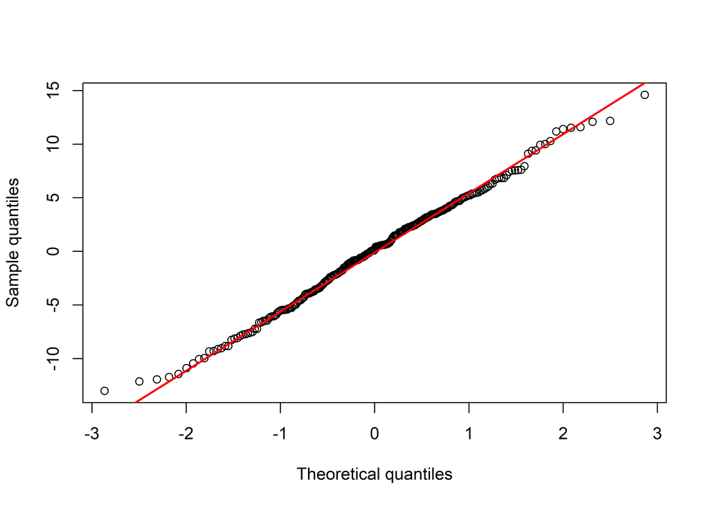

```r
# Graphical assessment of residual normality
qqnorm(residuals(mod_fam), main = "", xlab = "Theoretical quantiles", ylab = "Sample quantiles")
qqline(residuals(mod_fam), col = "red", lwd = 2)
```

```r
# Checking homogeneity of variances
var.test(altura ~ family, data = data_fam)
```

```
##
##  F test to compare two variances
##
## data:  altura by family
## F = 1.22, num df = 107, denom df = 132, p-value = 0.2767
## alternative hypothesis: true ratio of variances is not equal to 1
## 95 percent confidence interval:
##  0.8521255 1.7587891
## sample estimates:
## ratio of variances
##           1.219971
```

```r
# Comparing mean height between families
t.test(altura ~ family, data = data_fam, alternative = "two.sided", var.equal = TRUE)
```

```
##
##  Two Sample t-test
##
## data:  altura by family
## t = -0.13653, df = 239, p-value = 0.8915
## alternative hypothesis: true difference in means between group Euphorbiaceae and group Moraceae is not equal to 0
## 95 percent confidence interval:
##  -1.466851  1.276709
## sample estimates:
## mean in group Euphorbiaceae      mean in group Moraceae
##                    15.81222                    15.90729
```

```r
# The same two-group comparison can also be expressed as a one-way ANOVA
summary(mod_fam)
```

```
##              Df Sum Sq Mean Sq F value Pr(>F)
## family        1      1   0.539   0.019  0.892
## Residuals   239   6907  28.902
```

This section compares mean height between two botanical families. The example illustrates the use of a two-sample Student’s t-test and the evaluation of model assumptions based on residual normality and variance homogeneity. Because the homogeneity of variances assumption was considered acceptable, the t-test was performed assuming equal variances. A one-way ANOVA with two groups is also shown to illustrate that, in this case, ANOVA and the two-sample t-test address the same general hypothesis of equal group means.

## 4.3. Comparing the proportion of multi-stemmed individuals between two families

```r
# Creating a table with the variables of interest
prop_family <- data_fam %>%
  group_by(family) %>%
  summarise(n_total = n(), n_multistemmed = sum(multicaule == 1), prop_multistemmed = n_multistemmed / n_total, .groups = "drop") %>%
  arrange(desc(n_total))

prop_family
```

```
## # A tibble: 2 × 4
##   family        n_total n_multistemmed prop_multistemmed
##   <chr>           <int>          <int>             <dbl>
## 1 Moraceae          133             18            0.135
## 2 Euphorbiaceae     108              5            0.0463
```

```r
# Comparing the proportion of multi-stemmed individuals between families
prop.test(x = prop_family$n_multistemmed, n = prop_family$n_total, alternative = "two.sided")
```

```
##
##  2-sample test for equality of proportions with continuity correction
##
## data:  prop_family$n_multistemmed out of prop_family$n_total
## X-squared = 4.4911, df = 1, p-value = 0.03407
## alternative hypothesis: two.sided
## 95 percent confidence interval:
##  0.01029366 0.16779044
## sample estimates:
##    prop 1    prop 2
## 0.1353383 0.0462963
```

This section compares the proportion of multi-stemmed individuals between two botanical families. Because the response variable is binary, the analysis is based on counts of individuals with and without the attribute in each group. The proportion test evaluates whether the observed difference between family-level proportions is greater than expected under the null hypothesis of equal proportions.

## 4.4. Bootstrap confidence interval and permutation test

This section uses simulation-based inference to compare mean height between multi-stemmed and single stem individuals. First, bootstrap resampling is used to estimate the uncertainty associated with the observed difference in means and to construct a confidence interval. Then, a permutation test is used to evaluate the null hypothesis that height and multistem status are independent.

```r
# Observed difference in mean height
# The order c("No", "Yes") calculates mean height of non-bifurcated
# individuals minus mean height of bifurcated individuals.
d_hat <- data_trab %>%
  specify(altura ~ multicaule_l) %>%
  calculate(stat = "diff in means", order = c("No", "Yes"))

d_hat
```

```
## Response: altura (numeric)
## Explanatory: multicaule_l (factor)
## # A tibble: 1 × 1
##    stat
##   <dbl>
## 1  5.26
```

```r
# Bootstrap distribution of the difference in means
set.seed(333)
boot_bif <- data_trab %>%
  specify(altura ~ multicaule_l) %>%
  generate(reps = 10000, type = "bootstrap") %>%
  calculate(stat = "diff in means", order = c("No", "Yes"))

# Bootstrap confidence interval
ci_boot_bif <- boot_bif %>%
  get_confidence_interval(level = 0.95, type = "percentile")

ci_boot_bif
```

```
## # A tibble: 1 × 2
##   lower_ci upper_ci
##      <dbl>    <dbl>
## 1     4.85     5.66
```

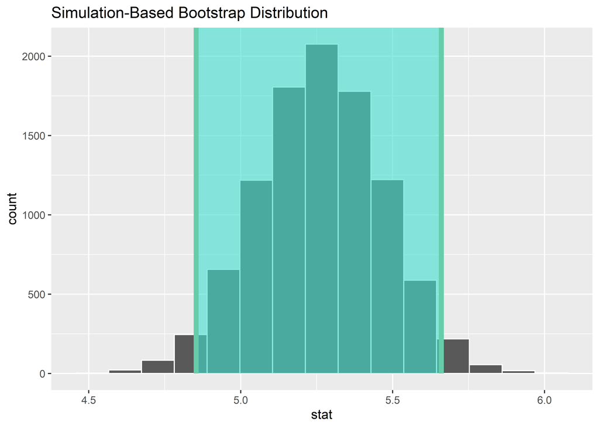

```r
# Visualizing the bootstrap confidence interval
boot_bif %>%
  visualise() +
  shade_confidence_interval(ci_boot_bif)
```

```r
# Permutation test for the null hypothesis of independence between height and bifurcation status
set.seed(333)
perm_bif <- data_trab %>%
  specify(altura ~ multicaule_l) %>%
  hypothesize(null = "independence") %>%
  generate(reps = 10000, type = "permute") %>%
  calculate(stat = "diff in means", order = c("No", "Yes"))

# Permutation p-value
p_perm_bif <- perm_bif %>%
  get_p_value(obs_stat = d_hat, direction = "two-sided")


# p-value
p_val <- p_perm_bif$p_value

if (p_val == 0) {
  paste("p <", 1 / 10000)
} else {
  paste("p =", round(p_val, 4))
}
```

```
## [1] "p < 1e-04"
```

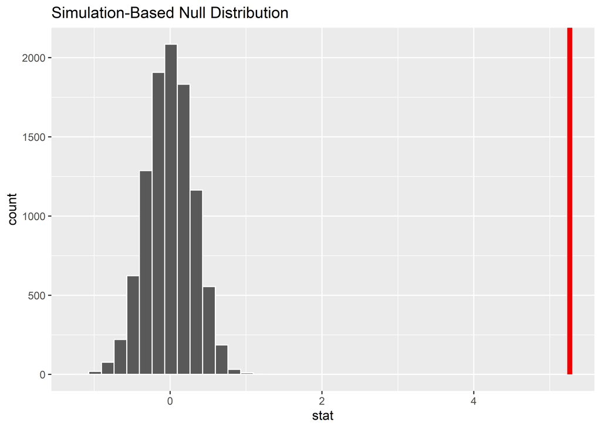

```r
# Visualizing the permutation test
perm_bif %>%
  visualise() +
  shade_p_value(obs_stat = d_hat, direction = "two-sided")
```

The bootstrap distribution represents the uncertainty around the observed difference in mean height between the two groups. If the confidence interval does not include zero, this suggests a difference in mean height between multi-stemmed and single stem individuals. The permutation test evaluates the same question under the null hypothesis of independence between height and multistem status. Small p-values indicate that the observed difference would be unlikely if multistem status and height were unrelated.

# 5. Sampling

```r
# General settings
z <- 1.96
relative_error <- 0.05
N <- nrow(data_trab)
```

## 5.1. Sample size based on relative error

```r
# Sample size based on relative error
n_dap <- (z^2 * (sd(data_trab$dap) / mean(data_trab$dap))^2) / relative_error^2
n_alt <- (z^2 * (sd(data_trab$altura) / mean(data_trab$altura))^2) / relative_error^2

n_dap
```

```
## [1] 643.1708
```

```r
n_alt
```

```
## [1] 408.3531
```

```r
# Finite population correction
n_dap_f <- n_dap / (1 + ((n_dap - 1) / N))
n_alt_f <- n_alt / (1 + ((n_alt - 1) / N))

n_dap_f
```

```
## [1] 564.6961
```

```r
n_alt_f
```

```
## [1] 375.2719
```

## 5.2. Simple random sampling

```r
# Simple random sampling
set.seed(333)
amo_aleatoria <- data_trab %>%
  slice_sample(n = round(n_dap, 0), replace = FALSE)

nrow(amo_aleatoria)
```

```
## [1] 643
```

```r
# Comparing sample estimates with population parameters
compare_sample(amo_aleatoria, data_trab, dap)
```

```
## # A tibble: 8 × 5
##   statistic population sample absolute_error relative_error_percent
##   <chr>          <dbl>  <dbl>          <dbl>                  <dbl>
## 1 mean            44.4   44.7         0.265                   0.597
## 2 median          36.6   36.4        -0.200                  -0.546
## 3 sd              28.7   29.9         1.21                    4.20
## 4 cv              64.7   67.0         2.32                    3.58
## 5 q25             23.3   23.4         0.0666                  0.286
## 6 q75             60.2   59.9        -0.255                  -0.424
## 7 p90             79.3   78.9        -0.320                  -0.404
## 8 p95            100.   103.          2.68                    2.68
```

## 5.3. Systematic sampling

```r
# Systematic sampling
set.seed(333)

k <- N / round(n_dap, 0)

inicio <- runif(1, min = 1, max = k)

indices_sistematicos <- floor(inicio + (0:(round(n_dap, 0) - 1)) * k)

indices_sistematicos <- indices_sistematicos[indices_sistematicos <= N]

amo_sistematica <- data_trab[indices_sistematicos, ]

nrow(amo_sistematica)
```

```
## [1] 643
```

```r
# Comparing sample estimates with population parameters
compare_sample(amo_sistematica, data_trab, dap)
```

```
## # A tibble: 8 × 5
##   statistic population sample absolute_error relative_error_percent
##   <chr>          <dbl>  <dbl>          <dbl>                  <dbl>
## 1 mean            44.4   45.5          1.06                   2.38
## 2 median          36.6   37.0          0.372                  1.02
## 3 sd              28.7   30.5          1.73                   6.03
## 4 cv              64.7   67.0          2.31                   3.56
## 5 q25             23.3   23.2         -0.104                 -0.445
## 6 q75             60.2   64.4          4.23                   7.03
## 7 p90             79.3   83.7          4.40                   5.55
## 8 p95            100.   107.           6.48                   6.47
```

## 5.4. Stratified sampling

```r
# Proportional stratified sampling by bed
set.seed(123)

alocacao <- data_trab %>%
  filter(sec_cant != "") %>%
  count(sec_cant, name = "N_h") %>%
  mutate(prop = N_h / sum(N_h), n_h_raw = prop * round(n_dap, 0), n_h = floor(n_h_raw), remainder = n_h_raw - n_h)

# Adjusting allocation to obtain exactly the target sample size
faltam <- round(n_dap, 0) - sum(alocacao$n_h)

alocacao <- alocacao %>%
  arrange(desc(remainder)) %>%
  mutate(n_h = n_h + if_else(row_number() <= faltam, 1L, 0L)) %>%
  select(sec_cant, N_h, n_h)

# Drawing the proportional stratified sample
amo_estratificada <- data_trab %>%
  filter(sec_cant != "") %>%
  inner_join(alocacao, by = "sec_cant") %>%
  group_by(sec_cant) %>%
  group_modify(~ slice_sample(.x, n = unique(.x$n_h), replace = FALSE)) %>%
  ungroup() %>%
  select(-N_h, -n_h)

nrow(amo_estratificada)
```

```
## [1] 643
```

```r
# Comparing sample estimates with population parameters
compare_sample(amo_estratificada, data_trab, dap)
```

```
## # A tibble: 8 × 5
##   statistic population sample absolute_error relative_error_percent
##   <chr>          <dbl>  <dbl>          <dbl>                  <dbl>
## 1 mean            44.4   44.2        -0.172                 -0.387
## 2 median          36.6   35.0        -1.60                  -4.37
## 3 sd              28.7   29.1         0.316                  1.10
## 4 cv              64.7   65.7         0.966                  1.49
## 5 q25             23.3   23.3        -0.0134                -0.0576
## 6 q75             60.2   60.4         0.220                  0.366
## 7 p90             79.3   80.3         1.04                   1.31
## 8 p95            100.   100.          0.0158                 0.0158
```

## 5.5. Cluster sampling

### 5.5.1. One-stage cluster sampling

```r
# One-stage cluster sampling
# Entire beds are selected until the accumulated number of individuals reaches the target sample size.
set.seed(123)

conglomerados <- data_trab %>%
  filter(sec_cant != "") %>%
  count(sec_cant, name = "N_cant")

conglomerados_sorteados <- conglomerados %>%
  slice_sample(prop = 1) %>%
  mutate(N_acum = cumsum(N_cant)) %>%
  filter(N_acum <= round(n_dap, 0) | lag(N_acum, default = 0) < round(n_dap, 0))

amo_conglomerados <- data_trab %>%
  filter(sec_cant %in% conglomerados_sorteados$sec_cant)

nrow(amo_conglomerados)
```

```
## [1] 659
```

```r
# Comparing sample estimates with population parameters
compare_sample(amo_conglomerados, data_trab, dap)
```

```
## # A tibble: 8 × 5
##   statistic population sample absolute_error relative_error_percent
##   <chr>          <dbl>  <dbl>          <dbl>                  <dbl>
## 1 mean            44.4   47.0          2.54                    5.72
## 2 median          36.6   39.0          2.38                    6.50
## 3 sd              28.7   31.0          2.26                    7.87
## 4 cv              64.7   66.0          1.32                    2.04
## 5 q25             23.3   23.7          0.366                   1.57
## 6 q75             60.2   61.6          1.41                    2.34
## 7 p90             79.3   88.8          9.54                   12.0
## 8 p95            100.   110.          10.3                    10.3
```

### 5.5.2. Two-stage cluster sampling

```r
# Two-stage cluster sampling
# First, beds are selected. Then, individuals are sampled within the selected beds.
set.seed(123)

n_canteiros <- 50

canteiros_sorteados <- data_trab %>%
  filter(sec_cant != "") %>%
  distinct(sec_cant) %>%
  slice_sample(n = n_canteiros)

base_canteiros <- data_trab %>%
  filter(sec_cant %in% canteiros_sorteados$sec_cant)

amo_conglomerados_2est <- base_canteiros %>%
  slice_sample(n = round(n_dap, 0), replace = FALSE)

nrow(amo_conglomerados_2est)
```

```
## [1] 643
```

```r
# Comparing sample estimates with population parameters
compare_sample(amo_conglomerados_2est, data_trab, dap)
```

```
## # A tibble: 8 × 5
##   statistic population sample absolute_error relative_error_percent
##   <chr>          <dbl>  <dbl>          <dbl>                  <dbl>
## 1 mean            44.4   45.3          0.926                  2.08
## 2 median          36.6   38.0          1.36                   3.71
## 3 sd              28.7   29.9          1.15                   3.99
## 4 cv              64.7   65.9          1.21                   1.87
## 5 q25             23.3   23.2         -0.114                 -0.489
## 6 q75             60.2   60.5          0.320                  0.532
## 7 p90             79.3   79.9          0.640                  0.807
## 8 p95            100.   105.           5.15                   5.14
```

## 5.6. Comparing sampling strategies

```r
# Organizing sampling outputs in a named list
samples_list <- list(
  "Simple random sampling" = amo_aleatoria,
  "Systematic sampling" = amo_sistematica,
  "Stratified sampling" = amo_estratificada,
  "One-stage cluster sampling" = amo_conglomerados,
  "Two-stage cluster sampling" = amo_conglomerados_2est
)
```

```r
# Comparing each sample with the reference population
sampling_comparison <- imap_dfr(
  samples_list,
  ~ compare_sample(.x, data_trab, dap) %>%
    mutate(method = .y)
) %>%
  relocate(method)

sampling_comparison
```

```
## # A tibble: 40 × 6
##    method      statistic population sample absolute_error relative_error_percent
##    <chr>       <chr>          <dbl>  <dbl>          <dbl>                  <dbl>
##  1 Simple ran… mean            44.4   44.7         0.265                   0.597
##  2 Simple ran… median          36.6   36.4        -0.200                  -0.546
##  3 Simple ran… sd              28.7   29.9         1.21                    4.20
##  4 Simple ran… cv              64.7   67.0         2.32                    3.58
##  5 Simple ran… q25             23.3   23.4         0.0666                  0.286
##  6 Simple ran… q75             60.2   59.9        -0.255                  -0.424
##  7 Simple ran… p90             79.3   78.9        -0.320                  -0.404
##  8 Simple ran… p95            100.   103.          2.68                    2.68
##  9 Systematic… mean            44.4   45.5         1.06                    2.38
## 10 Systematic… median          36.6   37.0         0.372                   1.02
## # ℹ 30 more rows
```

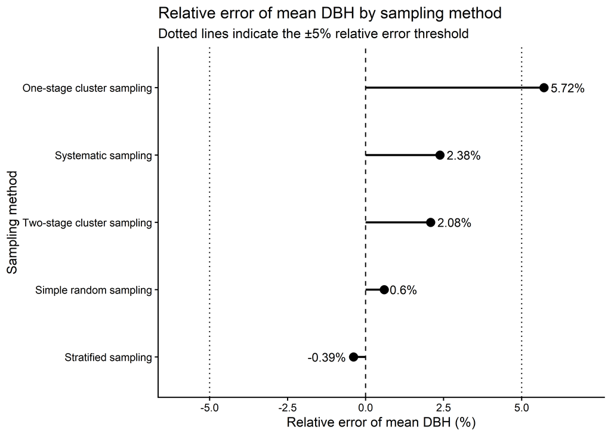

```r
# Plotting relative error of mean DBH
sampling_comparison %>%
  filter(statistic == "mean") %>%
  mutate(method = reorder(method, abs(relative_error_percent))) %>%
  ggplot(aes(x = relative_error_percent, y = method)) +
  geom_vline(xintercept = 0, linetype = "dashed") +
  geom_vline(xintercept = c(-5, 5), linetype = "dotted") +
  geom_segment(aes(x = 0, xend = relative_error_percent, yend = method), linewidth = 0.8) +
  geom_point(size = 3) +
  geom_text(aes(label = paste0(round(relative_error_percent, 2), "%"), hjust = if_else(relative_error_percent >= 0, -0.2, 1.2)), size = 3.5) +
  scale_x_continuous(limits = c(-6, 7), breaks = c(-5, -2.5, 0, 2.5, 5)) +
  labs(x = "Relative error of mean DBH (%)", y = "Sampling method", title = "Relative error of mean DBH by sampling method", subtitle = "Dotted lines indicate the ±5% relative error threshold") +
  theme_classic()
```

This section introduces different sampling strategies using the arboretum census as the reference population. First, sample size is estimated based on the desired relative error for DBH and height. Then, different sampling designs are applied, including simple random sampling, systematic sampling, stratified sampling, and cluster sampling. For each design, the sample mean and standard deviation of DBH are compared with the corresponding values calculated from the reference population. The objective is not to define a definitive sampling protocol, but to illustrate how different sampling designs can produce different estimates from the same population.